# Re-analysis of Cao et al. 2025 (GSE207192)

### Plots

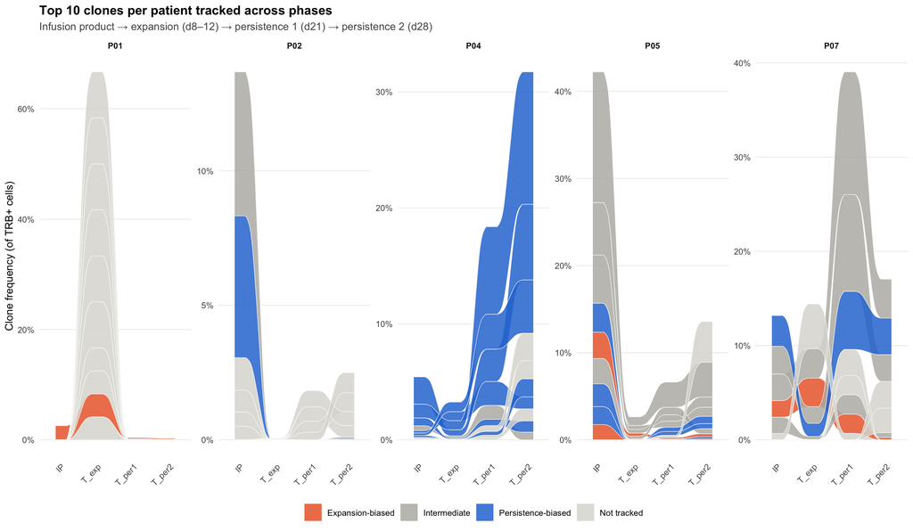

```r
library(ggalluvial)
topn <- cnt[, .(mx = max(freq)), by = .(pt, clone)][order(pt, -mx)][, head(.SD, 10), by = pt]
al <- cnt[topn[, .(pt, clone)], on = .(pt, clone)]
al <- al[CJ(pt = unique(al$pt), clone = unique(al$clone), phase = levels(cnt$phase), unique = TRUE),
         on = .(pt, clone, phase)][topn[, .(pt, clone)], on = .(pt, clone)]
al[is.na(freq), freq := 0]
al[, fate := fate[!is.na(fate)][1], by = .(pt, clone)]
al[is.na(fate), fate := "Not tracked"]
al[, fate := factor(fate, levels = c("Expansion-biased", "Intermediate", "Persistence-biased", "Not tracked"))]

fate_cols <- c("Expansion-biased" = "#eb6834", "Intermediate" = "#b8b7b1",
               "Persistence-biased" = "#2a78d6", "Not tracked" = "#dcdbd6")
ggplot(al, aes(x = phase, y = freq, alluvium = clone, fill = fate)) +
  geom_alluvium(aes(group = clone), width = 0.3, alpha = 0.85, decreasing = FALSE,
                colour = "#fcfcfb", linewidth = 0.2) +
  facet_wrap(~ pt, nrow = 1, scales = "free_y") +
  scale_fill_manual(values = fate_cols, name = NULL, drop = FALSE) +
  scale_y_continuous(labels = scales::percent_format(accuracy = 1)) +
  labs(title = "Top 10 clones per patient tracked across phases",
       subtitle = "Infusion product → expansion (d8–12) → persistence 1 (d21) → persistence 2 (d28)",
       x = NULL, y = "Clone frequency (of TRB+ cells)") +
  theme_minimal(base_size = 10) +
  theme(panel.grid.major.x = element_blank(), panel.grid.minor = element_blank(),
        panel.grid.major.y = element_line(colour = "#ebeae6", linewidth = 0.3),
        axis.text.x = element_text(angle = 45, hjust = 1, colour = "#52514e"),
        plot.title = element_text(face = "bold"), plot.subtitle = element_text(colour = "#52514e"),
        strip.text = element_text(face = "bold"), legend.position = "bottom")
```

**Important**

The clones with the most dramatic fate are therefore **excluded from the expansion-versus- persistence comparison**, and their disappearance is confounded with transduction status (the product is unsorted, post-infusion is CAR+ sorted). Any statement about what distinguishes persistent clones applies only to clones that survived detectably at all.

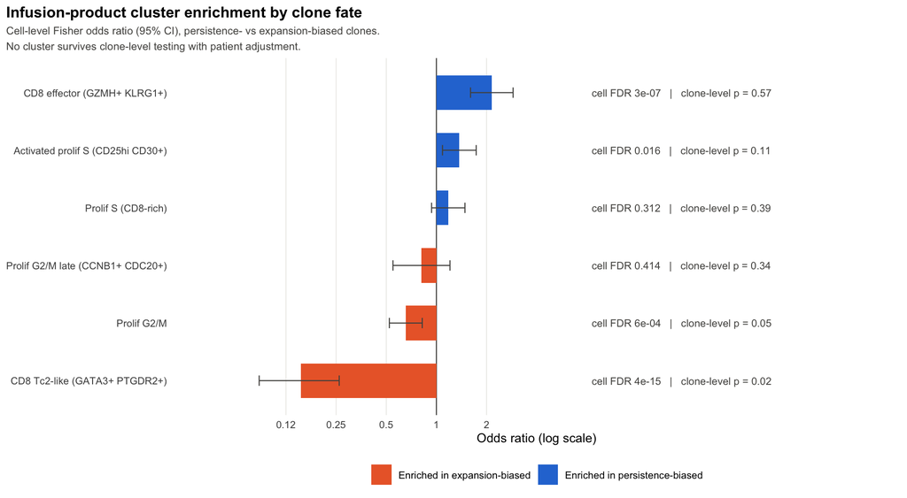

```r
od <- ors[n_pers + n_exp >= 20][order(OR)]
od[, cluster := factor(cluster, levels = cluster)]
od[, dir := fifelse(OR > 1, "Enriched in persistence-biased", "Enriched in expansion-biased")]
od[, lab := sprintf("cell FDR %s   |   clone-level p = %.2f",
                    ifelse(fdr_cell < 1e-3, format(fdr_cell, digits = 1, scientific = TRUE),
                           sprintf("%.3f", fdr_cell)), p_clone)]
ggplot(od, aes(x = log2(OR), y = cluster, fill = dir)) +
  geom_vline(xintercept = 0, colour = "#52514e", linewidth = 0.4) +
  geom_col(width = 0.6) +
  geom_errorbar(aes(xmin = log2(lo), xmax = log2(hi)), width = 0.18,
                colour = "#52514e", linewidth = 0.4, orientation = "y") +
  geom_text(aes(label = lab), x = 3.1, hjust = 0, size = 2.9, colour = "#52514e") +
  scale_fill_manual(values = c("Enriched in persistence-biased" = "#2a78d6",
                               "Enriched in expansion-biased"   = "#eb6834"), name = NULL) +
  scale_x_continuous(breaks = c(-3,-2,-1,0,1), labels = function(x) round(2^x, 2),
                     limits = c(-4.6, 8.6)) +
  labs(title = "Infusion-product cluster enrichment by clone fate",
       subtitle = paste("Cell-level Fisher odds ratio (95% CI), persistence- vs expansion-biased clones.",
                        "\nNo cluster survives clone-level testing with patient adjustment."),
       x = "Odds ratio (log scale)", y = NULL) +
  theme_minimal(base_size = 10) +
  theme(panel.grid.major.y = element_blank(), panel.grid.minor = element_blank(),
        panel.grid.major.x = element_line(colour = "#ebeae6", linewidth = 0.3),
        plot.title = element_text(face = "bold"), plot.title.position = "plot",
        plot.subtitle = element_text(colour = "#52514e", size = 8.5, lineheight = 1.2),
        legend.position = "bottom")
```

Each bar carries both verdicts deliberately: the cell-level FDR a naive analysis would report, and the clone-level patient-adjusted p-value that supersedes it. The CD8 effector bar (OR 2.14, cell FDR 3.1e-07, clone-level p = 0.57) is the clearest case of the gap.

Figures are written to `figures/`.

**Warning**

**But it attenuates under stricter measurement filters**: restricting to better-observed clones gives p = 0.0012 (n = 76) → 0.099 (n = 48) → 0.109 (n = 34) → 0.83 (n = 23). The effect size stays negative and similar in the middle strata, so this is consistent with power loss rather than artefact, but it is not robust enough to call established. Treat as a hypothesis: lower CAR expression → less tonic signalling → better persistence is known CAR-T biology, and this data is consistent with it, but 76 clones in 5 patients cannot establish it.

```r
fwrite(grid[, .(pt, time, clone, prod_count, prod_freq, prod_car_frac, tp_total, obs,
                expected, p_two, fdr, contraction_powered, call)],
       file.path(proc_dir, "clone_tracking.csv.gz"))
fwrite(cl_ph[, .(pt, clone, prod_count, prod_freq, obs_peak, tot_peak, obs_persistence,
                 tot_persistence, p_shift, fdr_shift, phase_class)],
       file.path(proc_dir, "clone_phase_shift.csv.gz"))
rm(grid, g2, cl_ph, jm, jm2, prod, prod_phen, post_tp, tp_n, phase, ph, cc, prod_n, found,
   drop_pt, both, a, b, m, n, k, A, B, M, N2, K, eps, p, v, tt, oo, fit)
invisible(gc())
```

## Save objects

```r
saveRDS(pre,  file.path(proc_dir, "seurat_pre_infusion_annotated.rds"))
saveRDS(post, file.path(proc_dir, "seurat_post_infusion_annotated.rds"))
```